# Kaggle_House_Price

Fan Gong

2017/9/1

# Housing Price Analysis

## Feature Engineering

```r
library(dplyr)
library(e1071)
library(ggplot2)
library(corrplot)
library(reshape2)
library(glmnet)
library(caret)
library(xgboost)
```

### Problem Overview

First let me look at each variable and do a philosophical analysis about their meaning and importance.

```r
df = read.csv("/Users/gongfan/Desktop/kaggle/train.csv", stringsAsFactors = F)
df_test = read.csv("/Users/gongfan/Desktop/kaggle/test.csv", stringsAsFactors = F)
#Column Names
colnames(df)
```

```
##  [1] "Id"            "MSSubClass"    "MSZoning"      "LotFrontage"
##  [5] "LotArea"       "Street"        "Alley"         "LotShape"
##  [9] "LandContour"   "Utilities"     "LotConfig"     "LandSlope"
## [13] "Neighborhood"  "Condition1"    "Condition2"    "BldgType"
## [17] "HouseStyle"    "OverallQual"   "OverallCond"   "YearBuilt"
## [21] "YearRemodAdd"  "RoofStyle"     "RoofMatl"      "Exterior1st"
## [25] "Exterior2nd"   "MasVnrType"    "MasVnrArea"    "ExterQual"
## [29] "ExterCond"     "Foundation"    "BsmtQual"      "BsmtCond"
## [33] "BsmtExposure"  "BsmtFinType1"  "BsmtFinSF1"    "BsmtFinType2"
## [37] "BsmtFinSF2"    "BsmtUnfSF"     "TotalBsmtSF"   "Heating"
## [41] "HeatingQC"     "CentralAir"    "Electrical"    "X1stFlrSF"
## [45] "X2ndFlrSF"     "LowQualFinSF"  "GrLivArea"     "BsmtFullBath"
## [49] "BsmtHalfBath"  "FullBath"      "HalfBath"      "BedroomAbvGr"
## [53] "KitchenAbvGr"  "KitchenQual"   "TotRmsAbvGrd"  "Functional"
## [57] "Fireplaces"    "FireplaceQu"   "GarageType"    "GarageYrBlt"
## [61] "GarageFinish"  "GarageCars"    "GarageArea"    "GarageQual"
## [65] "GarageCond"    "PavedDrive"    "WoodDeckSF"    "OpenPorchSF"
## [69] "EnclosedPorch" "X3SsnPorch"    "ScreenPorch"   "PoolArea"
## [73] "PoolQC"        "Fence"         "MiscFeature"   "MiscVal"
## [77] "MoSold"        "YrSold"        "SaleType"      "SaleCondition"
## [81] "SalePrice"
```

In order to have some discipline in our analysis, I divide all the variables into three groups: **building**, **space** or **location**. When I say ‘bulding’, I mean a variable that relates to the physical characteristics of the building. When I say ‘space’, I mean a variable that reports space properties of the house. Finally, when I say ‘location’, I mean a variable that gives inforamtion about the place where the house is located.

```r
feature_segmentation = read.csv("Feature_Segmentation.csv")
head(feature_segmentation[,4:6])
```

```
##      Building       Space     Location
## 1  MSSubClass     LotArea     MSZoning
## 2      Street  MasVnrArea  LotFrontage
## 3       Alley  BsmtFinSF1 Neighborhood
## 4    LotShape  BsmtFinSF2   Condition1
## 5 LandContour   BsmtUnfSF   Condition2
## 6   Utilities TotalBsmtSF   GarageType
```

In order to make this table, I can have a general idea about all the variables. Besides, I am able to know some relationship between some variables based on their discription. For example, the variable `GarageCars` and `GarageArea` both illustrate the size of garage.

### Data Cleaning

After having an overview about the variables, I would like to then clean the data. Because the prerequisite for performing analysis is that there is no missing data in the datasets.

```r
#Combine the training and testing data
df_test$SalePrice = 0
df_combine = rbind(df, df_test)
#NA Check
na_check = apply(is.na(df_combine), 2, sum)
na_check[na_check != 0]
```

```
##     MSZoning  LotFrontage        Alley    Utilities  Exterior1st
##            4          486         2721            2            1
##  Exterior2nd   MasVnrType   MasVnrArea     BsmtQual     BsmtCond
##            1           24           23           81           82
## BsmtExposure BsmtFinType1   BsmtFinSF1 BsmtFinType2   BsmtFinSF2
##           82           79            1           80            1
##    BsmtUnfSF  TotalBsmtSF   Electrical BsmtFullBath BsmtHalfBath
##            1            1            1            2            2
##  KitchenQual   Functional  FireplaceQu   GarageType  GarageYrBlt
##            1            2         1420          157          159
## GarageFinish   GarageCars   GarageArea   GarageQual   GarageCond
##          159            1            1          159          159
##       PoolQC        Fence  MiscFeature     SaleType
##         2909         2348         2814            1
```

```r
length(na_check[na_check != 0])
```

```
## [1] 34
```

We could see that for `Alley`, `BsmtQual`, `BsmtCond`, `BsmtExposure`, `BsmtFinType1`, `BsmtFinType2`, `FireplaceQu`, `GarageType`, `GarageYrBlt`, `GarageFinish`, `GarageQual`, `GarageCond`, `poolQC`, `Fence`, `MiscFeature`, they have lots of missing data. But here `NA` represents one specific class, not represent for missing data. So we would better replace them to `None`.

1. For `LotFrontage`, it means linear feet of street connected to property. Since we have 486 missing values, it is better to exclude this variable.
2. For `BsmtFinSF1`, `BsmtFinSF2`, `BsmtUnfSF`, `TotalBsmtSF`, `BsmtFullBath`, `BsmtHalfBath`, `GarageCars`, `GarageArea`, the NAs here means there is no basement and no garage. So we could assign all these value to 0.
3. For `MSZoning`, `Utilities`, `Exterior1st`, `Exterior2nd`, `Electrical`, `KitchenQual`, `Functional`, `SaleType`, `MasVnrType` and `MasVnrArea`, I will use the most frequent value in each column.

```r
#Deal with missing data variables
##LotFrontage
df_combine = df_combine %>% select(-LotFrontage)

##Basement and Garage related variables
bsm_na_id = df_combine[is.na(df_combine$BsmtFinSF1),]$Id
new_row = df_combine %>% filter(Id %in% bsm_na_id) %>% mutate(BsmtFinSF1=0, BsmtFinSF2=0,BsmtUnfSF=0,TotalBsmtSF=0)
df_combine[df_combine$Id %in% bsm_na_id,] = new_row

ga_na_id = df_combine[is.na(df_combine$GarageCars),]$Id
new_row = df_combine %>% filter(Id %in% ga_na_id) %>% mutate(GarageCars=0, GarageArea=0)
df_combine[df_combine$Id %in% ga_na_id,] = new_row

bath_na_id = df_combine[is.na(df_combine$BsmtFullBath),]$Id
new_row = df_combine %>% filter(Id %in% bath_na_id) %>% mutate(BsmtFullBath=0, BsmtHalfBath=0)
df_combine[df_combine$Id %in% bath_na_id,] = new_row

##Impute most frequent value
variables = c('MSZoning', 'Utilities', 'Exterior1st', 'Exterior2nd', 'Electrical', 'KitchenQual', 'Functional', 'SaleType', 'MasVnrType', 'MasVnrArea')

Mode = function(x) {
  ux = unique(x)
  ux[which.max(tabulate(match(x, ux)))]
}

for(var in variables){
  if(is.numeric(df_combine[,var])){
    M = as.numeric(Mode(df_combine[,var]))
    df_combine[is.na(df_combine[,var]), var] = M
  }else{
    M = Mode(df_combine[,var])
    df_combine[is.na(df_combine[,var]), var] = M
  }
}

#Replace all the other NA to "None"
df_combine[is.na(df_combine)] = "None"

#Seperate the training and testing data
df = df_combine[1:1460,]
df_test = df_combine[-(1:1460),-ncol(df_combine)]
```

### Outlier Removal

Documentation for the Ames Housing Data indicates that there are outliers present in the training data

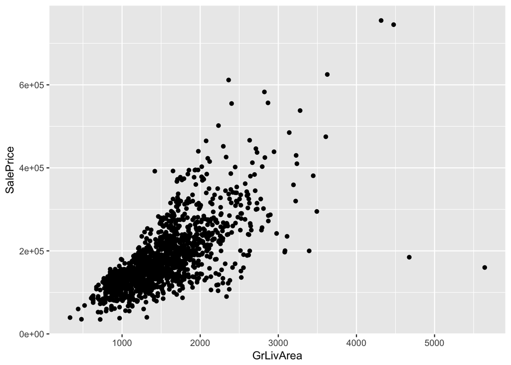

```r
ggplot(data = df, aes(x = GrLivArea, y = SalePrice)) + geom_point()
```

We can see at the bottom right two with extremely large GrLivArea that are of a low price. These values are huge outliers. Therefore, we can safely delete them.

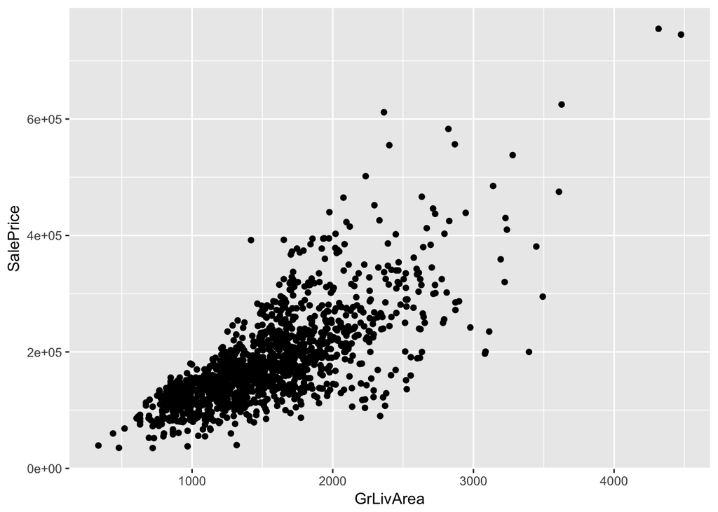

```r
df = df %>% filter(!(GrLivArea > 4000 & SalePrice < 300000))
ggplot(data = df, aes(x = GrLivArea, y = SalePrice)) + geom_point()
```

### Variable Transformation

I want our dataset to be strictly numeric values while remaining as much information as possible, I will have to transform any categoric into a binary feature using one-hot encoding.

I start by creating a new data frame of just the numeric features.

```r
#Exclude ID
df_combine = rbind(df[,-ncol(df)], df_test)
df_combine= df_combine[,-1]
#Extract numeric data
logic_numeric = sapply(df_combine, is.numeric)
df_numeric = df_combine[,logic_numeric]

#Extract categorical data
cat_features = names(which(sapply(df_combine, is.character)))
```

#### Ordinal Categorical Variable Transformation

```r
group.df = df_combine[1:nrow(df),]
group.df$SalePrice = df$SalePrice

#Function that groups a column by its features and returns the median saleprice for each unique feature.
group.prices = function(col) {
  group.table = group.df[,c(col, 'SalePrice', 'OverallQual')] %>% group_by_(col) %>%
    summarise(mean.Quality = round(mean(OverallQual),2),
      mean.Price = mean(SalePrice), n = n()) %>%
    arrange(mean.Quality)

  print(qplot(x=reorder(group.table[[col]], -group.table[['mean.Price']]), y=group.table[['mean.Price']]) +
    geom_bar(stat='identity', fill='cornflowerblue') +
    theme_minimal() +
    labs(x=col, y='Mean SalePrice') +
    theme(axis.text.x = element_text(angle = 45)))

  return(data.frame(group.table))
}

#Function to compute the mean overall quality for each quality
quality.mean = function(col) {
  group.table = df.combined[,c(col, 'OverallQual')] %>%
    group_by_(col) %>%
    summarise(mean.qual = mean(OverallQual)) %>%
    arrange(mean.qual)

  return(data.frame(group.table))
}

#Function that maps a categoric value to its corresponding numeric value and returns that column to the data frame
map.fcn = function(cols, map.list, df){
  for (col in cols){
    df[col] = as.numeric(map.list[df_combine[,col]])
  }
  return(df)
}
```

Any of the columns with the suffix ‘Qual’ or ‘Cond’ denote the quality or condition of that specific feature. Each of these columns have the potential values: TA, Fa, Gd, None, Ex, Po. We’ll compute the mean house prices for these unique values to get a better sense of what their abbreviations mean.

```r
#Categorical Variables (44)
logic_categorical = !(sapply(df, is.numeric))
names(logic_categorical)[logic_categorical]
```

```
##  [1] "MSZoning"      "Street"        "Alley"         "LotShape"
##  [5] "LandContour"   "Utilities"     "LotConfig"     "LandSlope"
##  [9] "Neighborhood"  "Condition1"    "Condition2"    "BldgType"
## [13] "HouseStyle"    "RoofStyle"     "RoofMatl"      "Exterior1st"
## [17] "Exterior2nd"   "MasVnrType"    "ExterQual"     "ExterCond"
## [21] "Foundation"    "BsmtQual"      "BsmtCond"      "BsmtExposure"
## [25] "BsmtFinType1"  "BsmtFinType2"  "Heating"       "HeatingQC"
## [29] "CentralAir"    "Electrical"    "KitchenQual"   "Functional"
## [33] "FireplaceQu"   "GarageType"    "GarageYrBlt"   "GarageFinish"
## [37] "GarageQual"    "GarageCond"    "PavedDrive"    "PoolQC"
## [41] "Fence"         "MiscFeature"   "SaleType"      "SaleCondition"
```

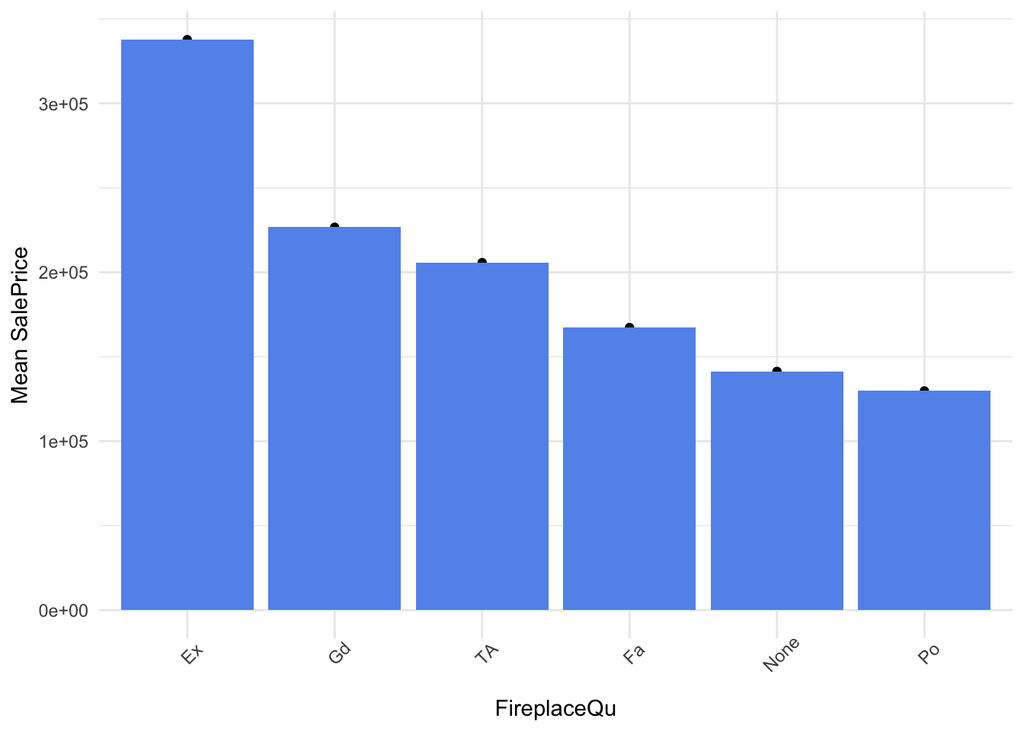

```
##   FireplaceQu mean.Quality mean.Price   n
## 1          Po         4.95   129764.1  20
## 2        None         5.46   141331.5 690
## 3          Fa         5.76   167298.5  33
## 4          TA         6.48   205723.5 313
## 5          Gd         6.88   226637.0 378
## 6          Ex         8.38   337712.5  24
```

```r
#Find the quality columns (8)
qual.cols = c('ExterQual', 'ExterCond', 'GarageQual', 'GarageCond', 'FireplaceQu', 'KitchenQual', 'HeatingQC', 'BsmtQual')

group.prices('FireplaceQu')
```

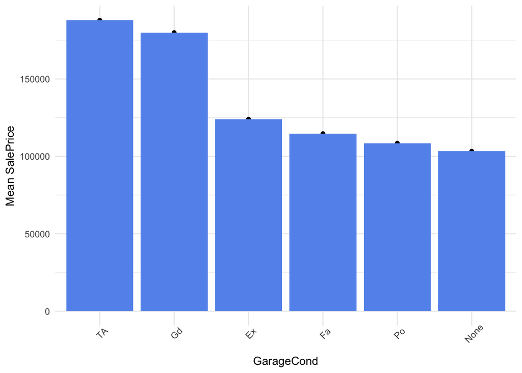

```
##   GarageCond mean.Quality mean.Price    n
## 1       None         4.60   103317.3   81
## 2         Fa         4.83   114654.0   35
## 3         Po         5.14   108500.0    7
## 4         Ex         5.50   124000.0    2
## 5         Gd         5.89   179930.0    9
## 6         TA         6.23   187909.2 1324
```

```r
group.prices('GarageCond')
```

From seeing the mean saleprices from a few of the quality and condition features we can infer that the abbreviations mean poor, fair, typical/average, good and excelent. We’ll map numeric values from 0-5 to their corresponding categoric values (including 0 for None) and combine that to our dataframe.

```r
qual.list = c('None' = 0, 'Po' = 1, 'Fa' = 2, 'TA' = 3, 'Gd' = 4, 'Ex' = 5)
df_numeric = map.fcn(qual.cols, qual.list, df_numeric)
```

Then we do the same thing to transform other categorical variables into numeric.

`BsmtExposure`:

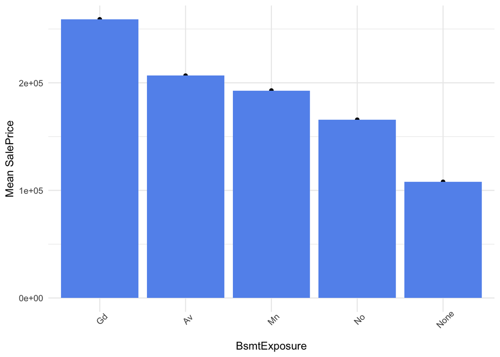

```
##   BsmtExposure mean.Quality mean.Price   n
## 1         None         4.37   107938.3  38
## 2           No         5.92   165652.3 953
## 3           Mn         6.25   192789.7 114
## 4           Av         6.57   206643.4 221
## 5           Gd         6.92   258982.5 132
```

```r
#BsmtExposure (8+1=9)
group.prices('BsmtExposure')
```

```r
bsmt.list = c('None' = 0, 'No' = 1, 'Mn' = 2, 'Av' = 3, 'Gd' = 4)
df_numeric = map.fcn(c('BsmtExposure'), bsmt.list, df_numeric)
```

`BsmtFinType1` and `BsmtFineType2`: `BsmtFinType1` and `BsmtFineType2` represent the quality of the 1st and 2nd finished areas. There should be some order between the different types of qualities, we’ll see if we can find a similarity between the 2 features.

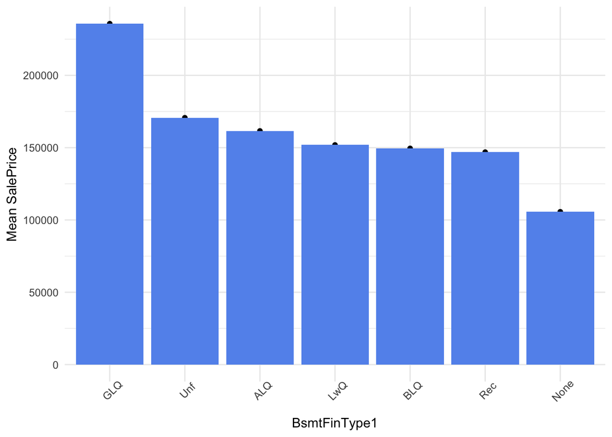

```
##   BsmtFinType1 mean.Quality mean.Price   n
## 1         None         4.30   105652.9  37
## 2          BLQ         5.35   149493.7 148
## 3          Rec         5.35   146889.2 133
## 4          LwQ         5.54   151852.7  74
## 5          ALQ         5.55   161573.1 220
## 6          Unf         6.20   170670.6 430
## 7          GLQ         7.03   235716.8 416
```

```r
group.prices('BsmtFinType1')
```

Here returning the mean sale prices might not be as helpful as computing the median basement areas for both columns to determine which quality is better than the other.

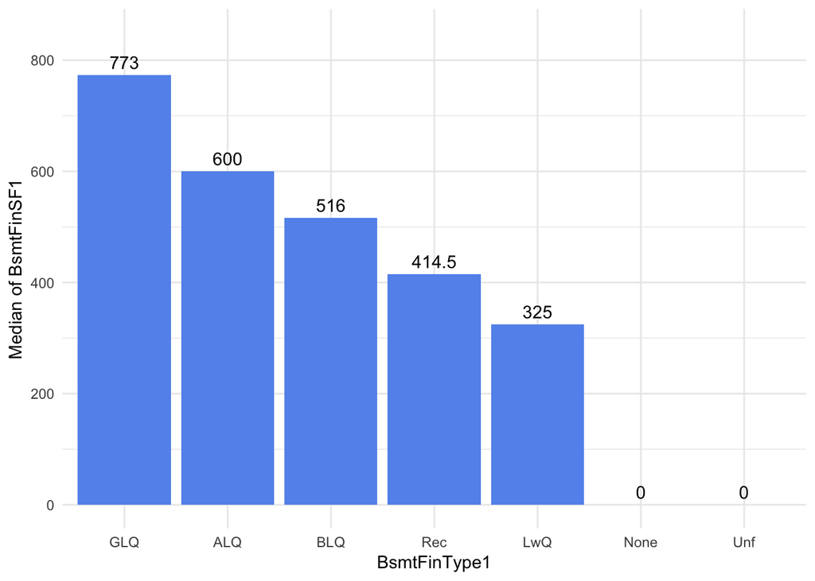

```r
df_combine[,c('BsmtFinType1', 'BsmtFinSF1')] %>%
  group_by(BsmtFinType1) %>%
  summarise(medianArea = median(BsmtFinSF1), counts = n()) %>%
  arrange(medianArea) %>%
  ggplot(aes(x=reorder(BsmtFinType1,-medianArea), y=medianArea)) +
  geom_bar(stat = 'identity', fill='cornflowerblue') +
  labs(x='BsmtFinType1', y='Median of BsmtFinSF1') +
  geom_text(aes(label = sort(medianArea)), vjust = -0.5) +
  scale_y_continuous(limits = c(0,850)) +
  theme_minimal()
```

```r
#BsmtFinType (9+2=11)
bsmt.fin.list = c('None' = 0, 'Unf' = 1, 'LwQ' = 2,'Rec'= 3, 'BLQ' = 4, 'ALQ' = 5, 'GLQ' = 6)
df_numeric = map.fcn(c('BsmtFinType1','BsmtFinType2'), bsmt.fin.list, df_numeric)
```

`Functional`: This feature doesn???t really tell us much and functionality is very vague to tie which other features have a correlation with it. We can compute the mean sale prices for each functional category and assign numeric values accordingly.

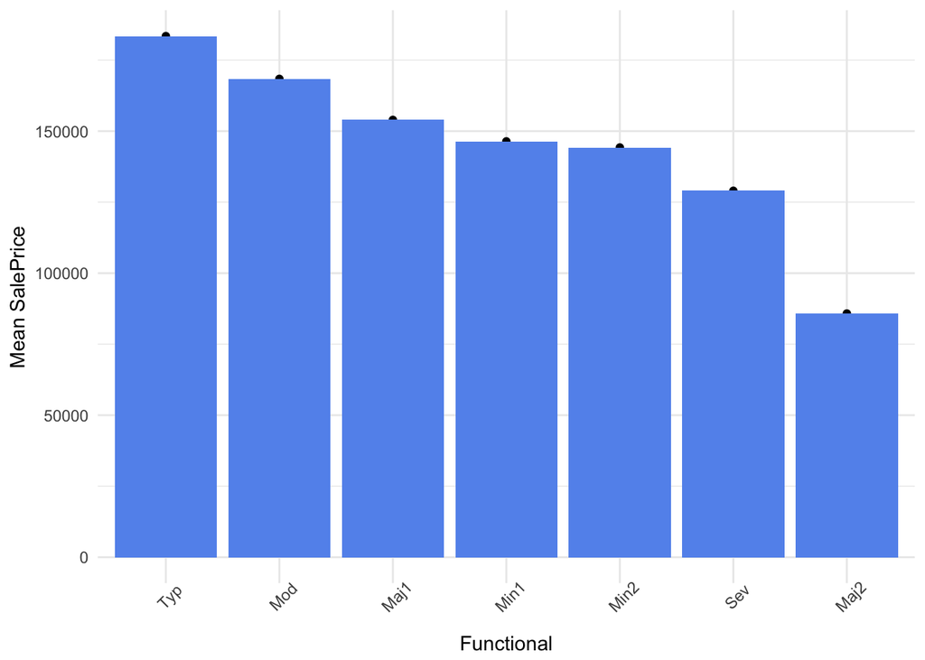

```
##   Functional mean.Quality mean.Price    n
## 1       Min2         4.97   144240.6   34
## 2       Maj2         5.00    85800.0    5
## 3       Min1         5.26   146385.5   31
## 4        Mod         5.40   168393.3   15
## 5       Maj1         5.50   153948.1   14
## 6        Sev         6.00   129000.0    1
## 7        Typ         6.16   183445.4 1358
```

```r
#Functional (11+1=12)
group.prices('Functional')
```

```r
functional.list = c('None' = 0, 'Sal' = 1, 'Sev' = 2, 'Maj2' = 3, 'Maj1' = 4, 'Mod' = 5, 'Min2' = 6, 'Min1' = 7, 'Typ'= 8)

df_numeric['Functional'] = as.numeric(functional.list[df_combine$Functional])
```

`GarageFinish` and `Fence` We???ll continue to do the same for GarageFinish and Fence:

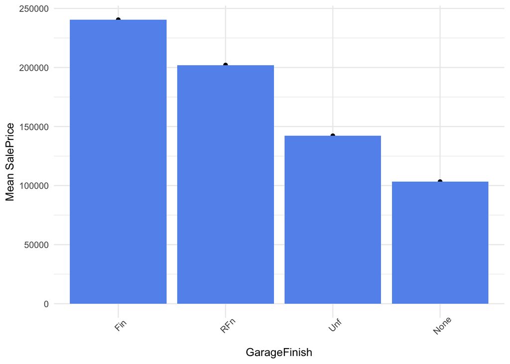

```
##   GarageFinish mean.Quality mean.Price   n
## 1         None         4.60   103317.3  81
## 2          Unf         5.40   142156.4 605
## 3          RFn         6.57   202068.9 422
## 4          Fin         7.05   240439.4 350
```

```r
#GarageFinish and Fence (12+2=14)
group.prices('GarageFinish')
```

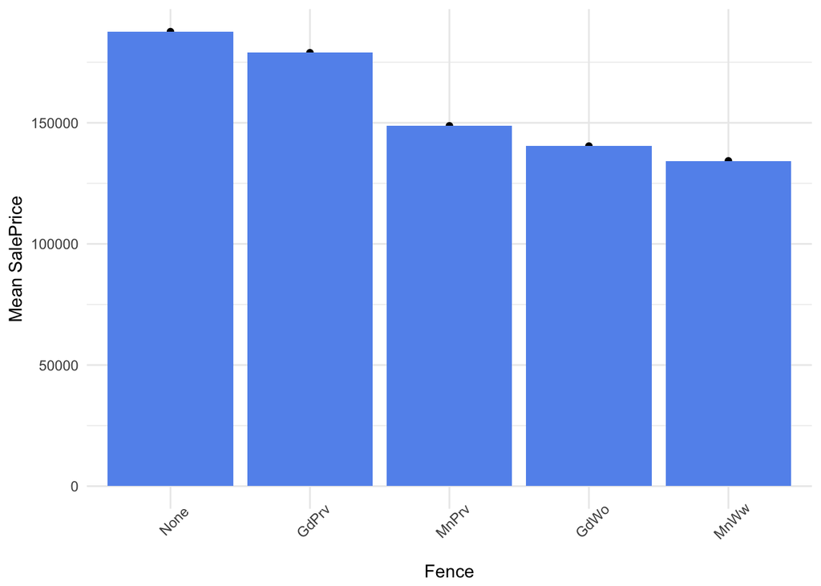

```
##   Fence mean.Quality mean.Price    n
## 1  GdWo         5.17   140379.3   54
## 2  MnWw         5.18   134286.4   11
## 3 MnPrv         5.45   148751.1  157
## 4  None         6.22   187622.7 1177
## 5 GdPrv         6.31   178927.5   59
```

```r
garage.fin.list = c('None' = 0,'Unf' = 1, 'RFn' = 1, 'Fin' = 2)
df_numeric['GarageFinish'] = as.numeric(garage.fin.list[df_combine$GarageFinish])

group.prices('Fence')
```

```r
fence.list = c('None' = 0, 'MnWw' = 1, 'GdWo' = 1, 'MnPrv' = 2, 'GdPrv' = 4)
df_numeric['Fence'] = as.numeric(fence.list[df_combine$Fence])
```

`MSSubClass`:

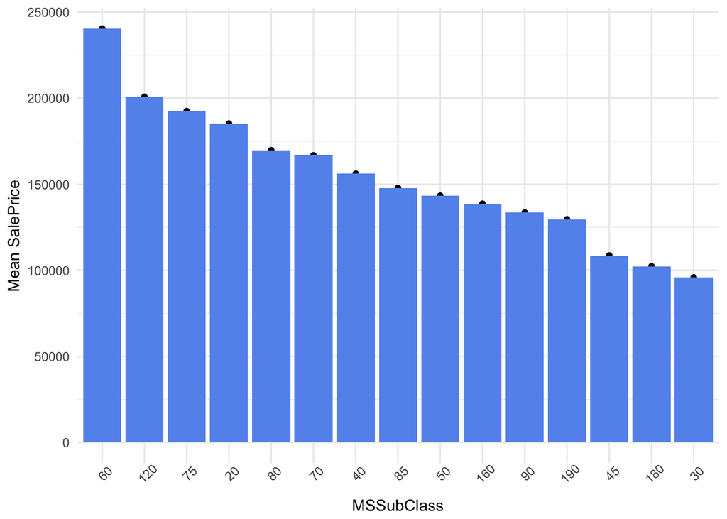

```
##    MSSubClass mean.Quality mean.Price   n
## 1          30         4.51   95829.72  69
## 2         180         4.60  102300.00  10
## 3          90         4.96  133541.08  52
## 4         190         4.97  129613.33  30
## 5          50         5.40  143302.97 144
## 6          85         5.45  147810.00  20
## 7          45         5.50  108591.67  12
## 8          40         5.75  156125.00   4
## 9          80         5.97  169736.55  58
## 10         20         6.03  185224.81 536
## 11         70         6.12  166772.42  60
## 12        160         6.14  138647.38  63
## 13         75         6.62  192437.50  16
## 14         60         7.04  240403.54 297
## 15        120         7.06  200779.08  87
```

```r
#MSSubClass (14+1=15)
group.prices('MSSubClass')
```

```r
MSdwelling.list = c('20' = 1, '30'= 0, '40' = 0, '45' = 0,'50' = 0, '60' = 1, '70' = 0, '75' = 0, '80' = 0, '85' = 0, '90' = 0, '120' = 1, '150' = 0, '160' = 0, '180' = 0, '190' = 0)

df_numeric['NewerDwelling'] = as.numeric(MSdwelling.list[as.character(df_combine$MSSubClass)])
```

#### Nominal Categorical Variable Transformation

Now for some of the nominal variables we can take one of the categories that is distinct from the others and create a binary feature that returns 1 if the house has that specific value and 0 if it does not.

`LotShape`:

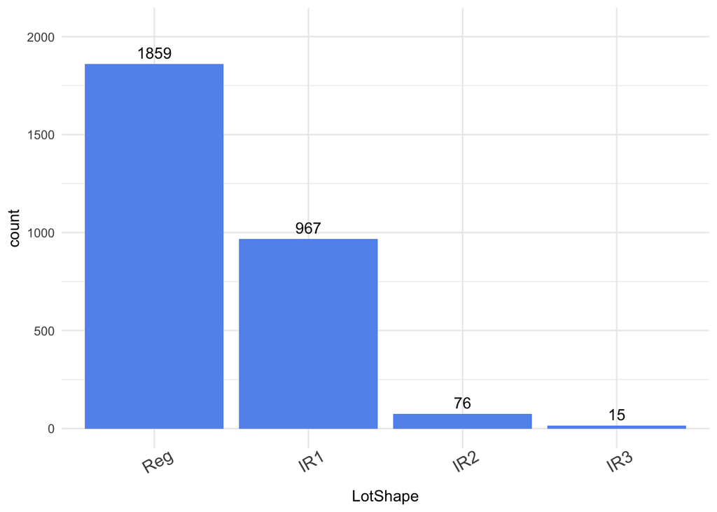

```r
#Helper function for plotting categoric data for easier data visualization.
plot.categoric = function(cols, df){
  for (col in cols) {
    order.cols = names(sort(table(df_combine[,col]), decreasing = TRUE))
    num.plot = qplot(df[,col]) +
      geom_bar(fill = 'cornflowerblue') +
      geom_text(aes(label = ..count..), stat='count', vjust=-0.5) +
      theme_minimal() +
      scale_y_continuous(limits = c(0,max(table(df[,col]))*1.1)) +
      scale_x_discrete(limits = order.cols) +
      xlab(col) +
      theme(axis.text.x = element_text(angle = 30, size=12))

    print(num.plot)
  }
}

plot.categoric('LotShape', df_combine)
```

We could see that LotShape has 3 values for having an irregular shape and only 1 for regular. We can create a binary column that returns 1 for houses with a regular lot shape and 0 for houses with any of the 3 irregular lot shapes. Using this method of turning a categoric feature into a binary column will ultimately help our data train better through boosted models without using numeric placeholders on nominal data.

```r
#LotShape (15+1=16)
df_numeric['RegularLotShape'] = (df_combine$LotShape == 'Reg') * 1
```

We will use this exact same method for: `LandContour`, `LandSlope`, `Electrical`, `GarageType`, `PavedDrive`, `MiscFeature`

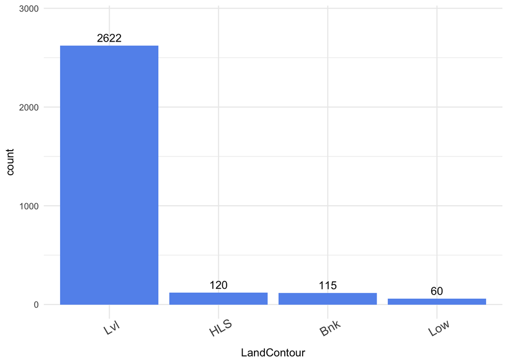

```r
#LandContour, LandSlope, Electrical, GarageType, PavedDrive, MiscFeature (16+6=22)
plot.categoric('LandContour', df_combine)
```

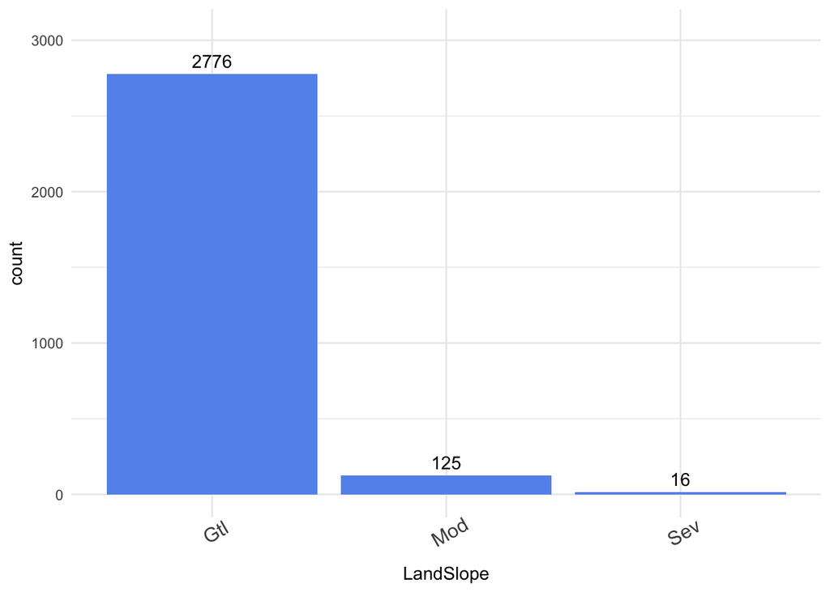

```r
df_numeric['LandLeveled'] = (df_combine$LandContour == 'Lvl') * 1

plot.categoric('LandSlope', df_combine)
```

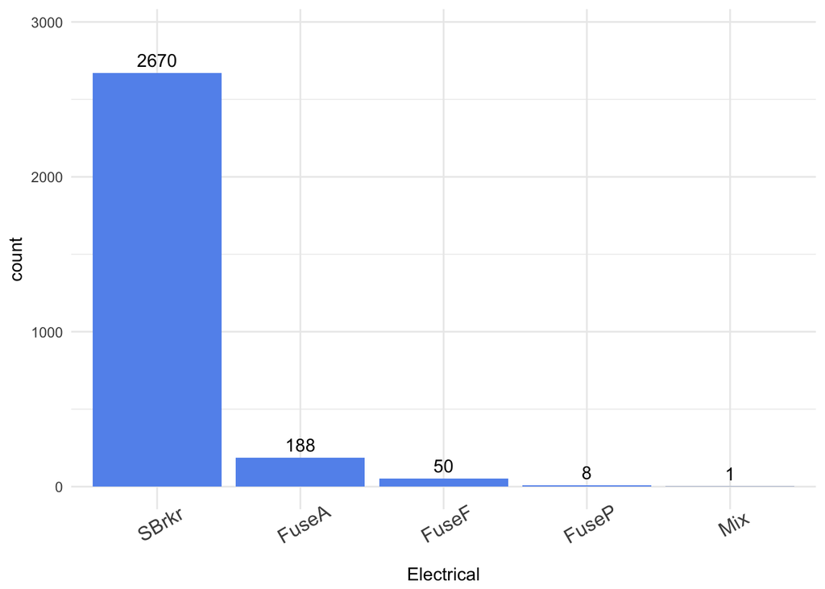

```r
df_numeric['LandSlopeGentle'] = (df_combine$LandSlope == 'Gtl') * 1

plot.categoric('Electrical', df_combine)
```

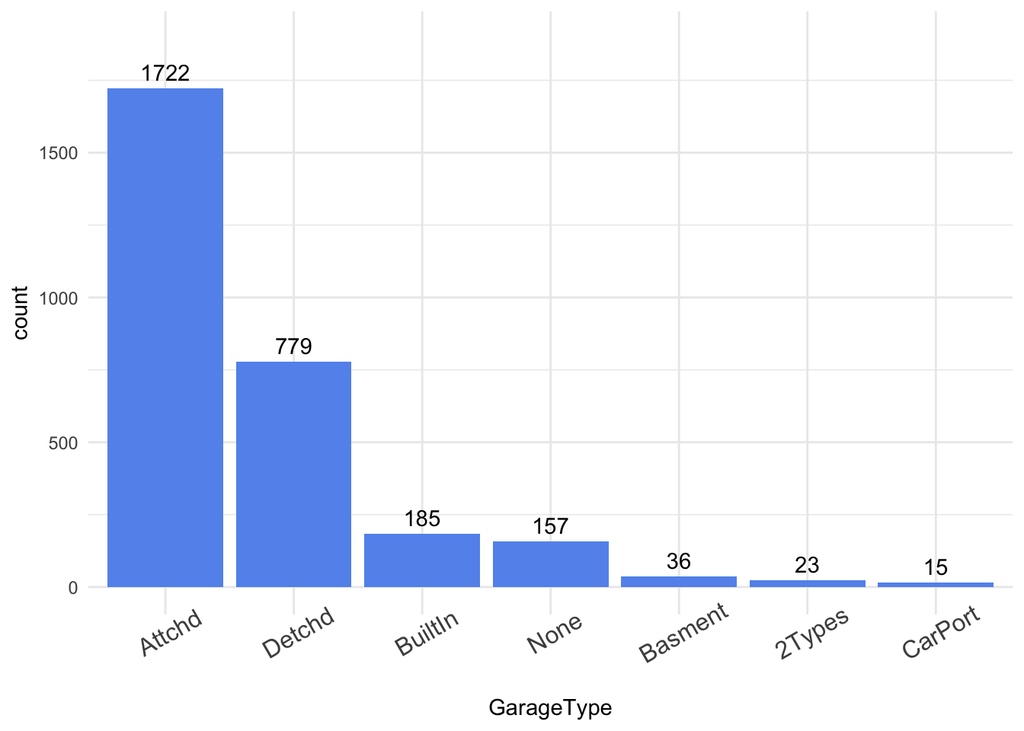

```r
df_numeric['ElectricalSB'] = (df_combine$Electrical == 'SBrkr') *1

plot.categoric('GarageType', df_combine)
```

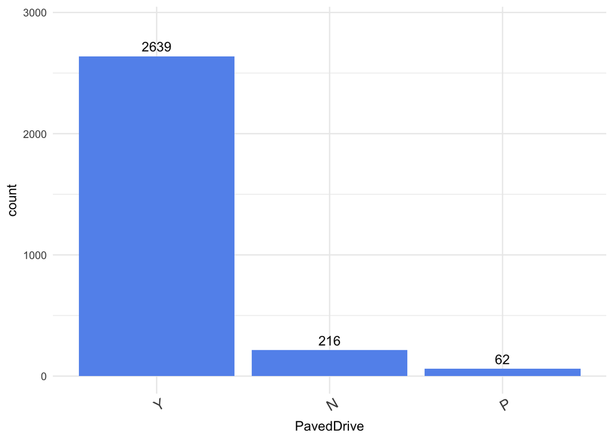

```r
df_numeric['GarageDetchd'] = (df_combine$GarageType == 'Detchd') * 1

plot.categoric('PavedDrive', df_combine)
```

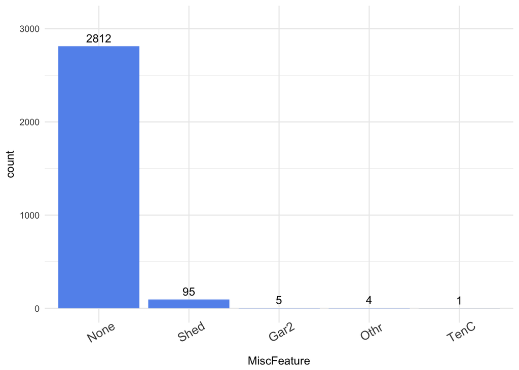

```r
df_numeric['HasPavedDrive'] = (df_combine$PavedDrive == 'Y') * 1

plot.categoric('MiscFeature', df_combine)
```

```r
df_numeric['HasShed'] = (df_combine$MiscFeature == 'Shed') * 1
```

`YearBuilt` and `YearRemodAdd`: Many of the houses recorded the same year for `YearBuilt` and `YearRemodAdd`. We can create a new column that records that a house was remodelled if the year it was built is different than the remodel year.

```r
#YearBuilt and YearRemodAdd (22+2=24)
df_numeric['Remodeled'] = (df_combine$YearBuilt != df_combine$YearRemodAdd) * 1
```

We can also create a column that seperates which houses have been recently remodelled vs those who are not. Houses that have been remodelled after the year they were sold will fall into this category.

```r
df_numeric['RecentRemodel'] = (df_combine$YearRemodAdd >= df_combine$YrSold) * 1
```

There can be potential value to homes who were sold the same year they were built as this could be an indicator that these houses were hot in the market.

```r
df_numeric['NewHouse'] = (df_combine$YearBuilt == df_combine$YrSold) * 1
```

We know how important the year a house was built and sold but what about the specific month it was sold? How do houses sold during summer compare to the other seasons?

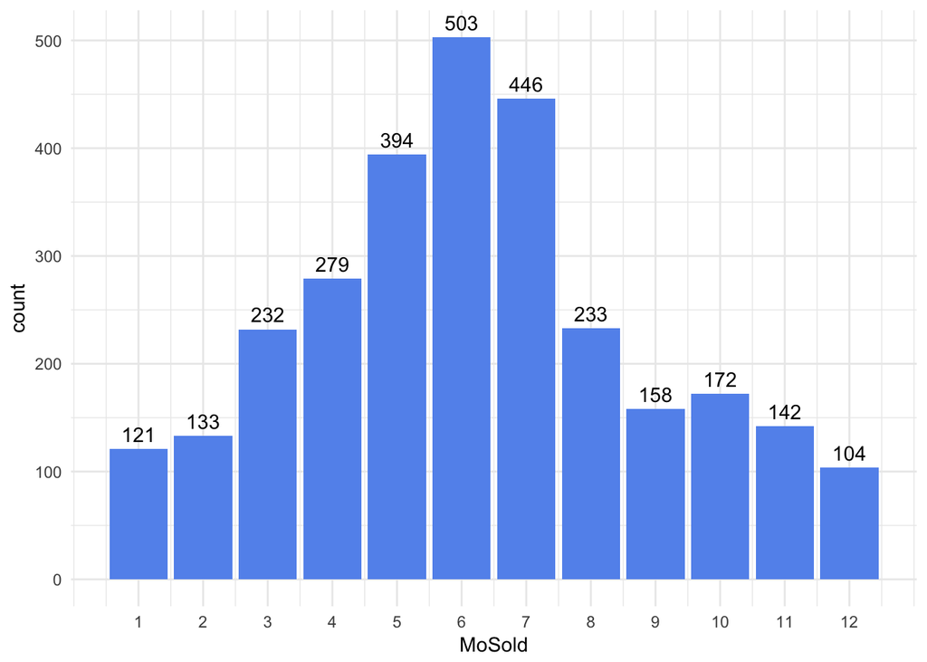

```r
ggplot(df_combine, aes(x=MoSold)) + geom_bar(fill = "cornflowerblue") + geom_text(aes(label = ..count..), stat = 'count', vjust = -0.5) + theme_minimal() + scale_x_continuous(breaks = 1:12)
```

The largest proportion of houses sold is during the summer months: May, June, july. Lets add a column that seperates the summer houses from the rest.

```r
df_numeric['HighSeason'] = (df_combine$MoSold %in% c(5,6,7)) * 1
```

`Neighborhoods`: What about which neighborhoods are more expensive than others?

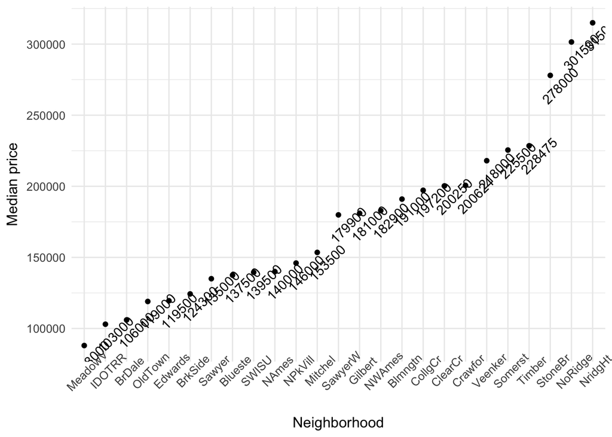

```r
#Neighborhood (24+1=25)
df[,c('Neighborhood', 'SalePrice')] %>% group_by(Neighborhood) %>% summarise(median.price = median(SalePrice, na.rm = T)) %>% arrange(median.price) %>% mutate(nhbr.sorted = factor(Neighborhood, levels=Neighborhood)) %>% ggplot(aes(x=nhbr.sorted, y=median.price)) +
  geom_point() +
  geom_text(aes(label = median.price, angle = 45), vjust = 2) + theme_minimal() + labs(x='Neighborhood', y = 'Median price') + theme(text = element_text(size=12), axis.text.x = element_text(angle = 45) )
```

Lets one-hot encode the more expensive neighborhoods and add that to our dataframe

```r
nbrh.rich = c('Crawfor', 'Somerst', 'Timber', 'StoneBr', 'NoRidge', 'NridgeHt')
df_numeric['NbrhRich'] = (df_combine$Neighborhood %in% nbrh.rich) * 1
```

How about a numeric mapping to the neighborhoods who have higher quality houses and run for larger sale prices?

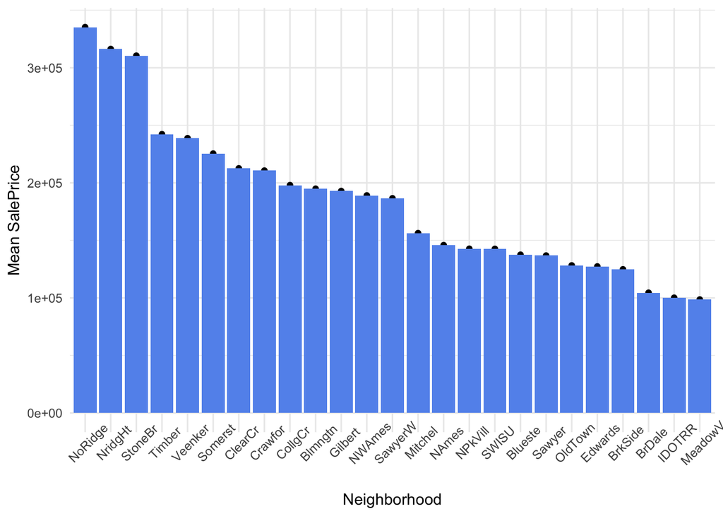

```
##    Neighborhood mean.Quality mean.Price   n
## 1       MeadowV         4.47   98576.47  17
## 2        IDOTRR         4.76  100123.78  37
## 3       Edwards         4.98  127318.57  98
## 4        Sawyer         5.03  136793.14  74
## 5       BrkSide         5.05  124834.05  58
## 6         NAmes         5.36  145847.08 225
## 7       OldTown         5.39  128225.30 113
## 8         SWISU         5.44  142591.36  25
## 9       Mitchel         5.59  156270.12  49
## 10       BrDale         5.69  104493.75  16
## 11      ClearCr         5.89  212565.43  28
## 12      Blueste         6.00  137500.00   2
## 13      NPkVill         6.00  142694.44   9
## 14      Crawfor         6.27  210624.73  51
## 15      SawyerW         6.32  186555.80  59
## 16       NWAmes         6.33  189050.07  73
## 17      Gilbert         6.56  192854.51  79
## 18      CollgCr         6.64  197965.77 150
## 19      Veenker         6.73  238772.73  11
## 20       Timber         7.16  242247.45  38
## 21      Blmngtn         7.18  194870.88  17
## 22      Somerst         7.34  225379.84  86
## 23      NoRidge         7.93  335295.32  41
## 24      StoneBr         8.16  310499.00  25
## 25      NridgHt         8.26  316270.62  77
```

```r
group.prices('Neighborhood')
```

```r
nbrh.map = c('MeadowV' = 0, 'IDOTRR' = 1, 'Sawyer' = 1, 'BrDale' = 1, 'OldTown' = 1, 'Edwards' = 1,
             'BrkSide' = 1, 'Blueste' = 1, 'SWISU' = 2, 'NAmes' = 2, 'NPkVill' = 2, 'Mitchel' = 2,
             'SawyerW' = 2, 'Gilbert' = 2, 'NWAmes' = 2, 'Blmngtn' = 2, 'CollgCr' = 2, 'ClearCr' = 3,
             'Crawfor' = 3, 'Veenker' = 3, 'Somerst' = 3, 'Timber' = 3, 'StoneBr' = 4, 'NoRidge' = 4,
             'NridgHt' = 4)

df_numeric['NeighborhoodBin'] = as.numeric(nbrh.map[df_combine$Neighborhood])
```

`SaleCondition`:

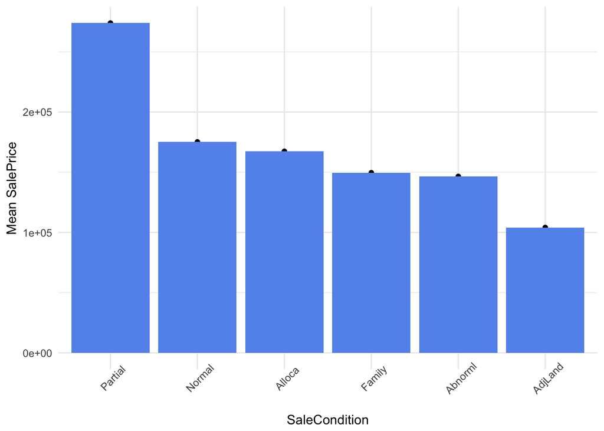

```
##   SaleCondition mean.Quality mean.Price    n
## 1       AdjLand         5.00   104125.0    4
## 2        Alloca         5.42   167377.4   12
## 3       Abnorml         5.57   146526.6  101
## 4        Family         5.80   149600.0   20
## 5        Normal         6.01   175202.2 1198
## 6       Partial         7.52   273916.4  123
```

```r
#SaleCondition (25+1=26)
group.prices('SaleCondition')
```

```r
df_numeric['PartialPlan'] = (df_combine$SaleCondition == 'Partial') * 1
```

`HeatingQC`

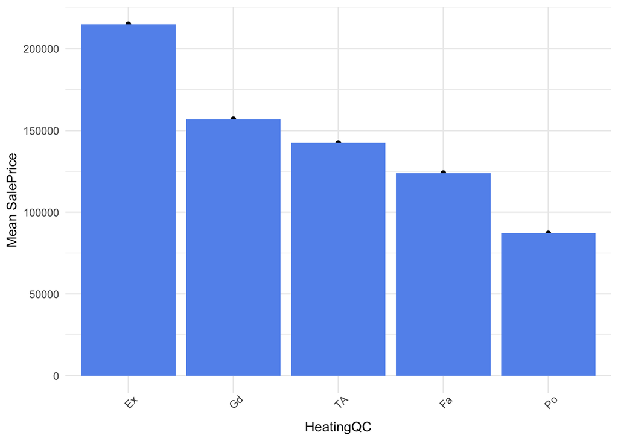

```
##   HeatingQC mean.Quality mean.Price   n
## 1        Fa         5.00   123919.5  49
## 2        Po         5.00    87000.0   1
## 3        TA         5.37   142362.9 428
## 4        Gd         5.70   156858.9 241
## 5        Ex         6.71   215029.6 739
```

```r
#HeatingQC (26+1=27)
group.prices('HeatingQC')
```

```r
heating.list = c('Po' = 0, 'Fa' = 1, 'TA' = 2, 'Gd' = 3, 'Ex' = 4)
df_numeric['HeatingScale'] = as.numeric(heating.list[df_combine$HeatingQC])
```

`MSZoning`

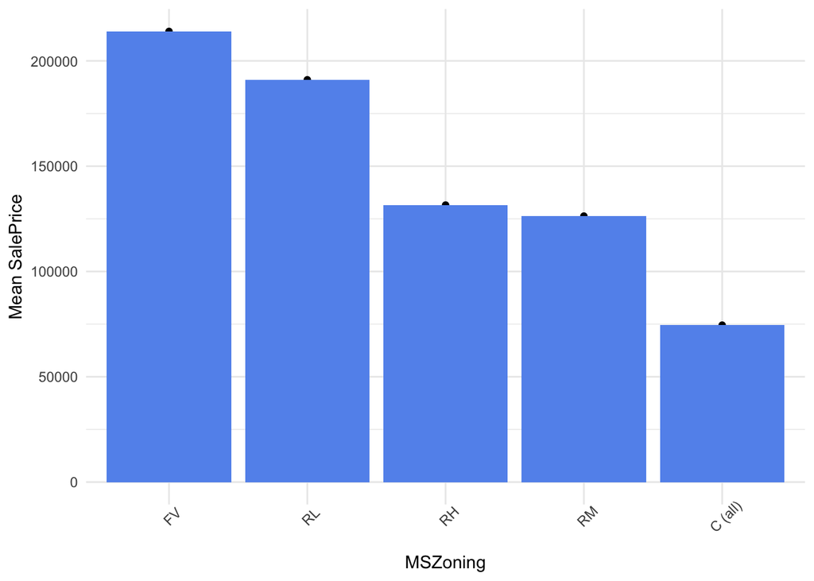

```
##   MSZoning mean.Quality mean.Price    n
## 1  C (all)         3.90    74528.0   10
## 2       RH         5.25   131558.4   16
## 3       RM         5.45   126316.8  218
## 4       RL         6.18   191037.4 1149
## 5       FV         7.20   214014.1   65
```

```r
group.prices('MSZoning')
```

#### Other Categorical Variable Transformation

For the rest of the categoric features we can one-hot encode each value to get as many splits in the data as possible since sparse data performs better for trees and xgboost.

```r
#Use dymmyVars
dummy = dummyVars(" ~ .",data=df_combine[,cat_features])
df_categoric = data.frame(predict(dummy,newdata=df_combine[,cat_features]))
```

#### Numeric Variable Transformation

##### New Numeric Variable Transformation

We know the area of the house is one of the most important factor that effects its sale price. So first I would like to calculate the `TotalArea` and `AreaInside` based the variable we have.

```r
area.cols = c('LotArea', 'MasVnrArea', 'BsmtFinSF1', 'BsmtFinSF2', 'BsmtUnfSF',
             'TotalBsmtSF', 'X1stFlrSF', 'X2ndFlrSF', 'GrLivArea', 'GarageArea', 'WoodDeckSF',
             'OpenPorchSF', 'EnclosedPorch', 'X3SsnPorch', 'ScreenPorch', 'LowQualFinSF', 'PoolArea')

df_numeric['TotalArea'] = as.numeric(rowSums(df_combine[, area.cols]))

df_numeric['AreaInside'] = as.numeric(df_combine$X1stFlrSF + df_combine$X2ndFlrSF)
```

We’ve seen how strong of an effect the year of a house built has on the house price, therefore, as this dataset collects houses up until 2010 we can determine how old a house is and how long ago the house was sold:

```r
df_numeric['Age'] = as.numeric(2010 - df_combine$YearBuilt)

# how many years since the house was remodelled and sold
df_numeric['TimeSinceSold'] = as.numeric(2010 - df_combine$YrSold)
```

##### Variable Normalization

I will first focus on the dependent variable (‘SalePrice’) and try to know a little bit more about it.

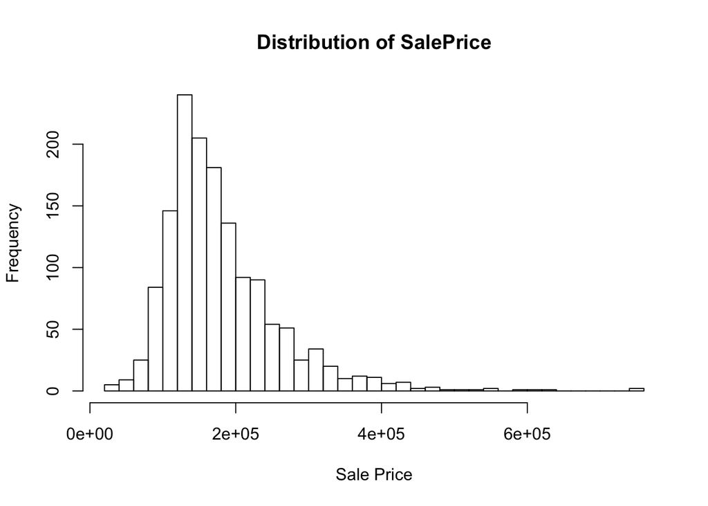

```r
hist(df$SalePrice, breaks = 50, main = "Distribution of SalePrice", xlab = "Sale Price")
```

```r
skewness(df$SalePrice)
```

```
## [1] 1.877427
```

```r
kurtosis(df$SalePrice)
```

```
## [1] 6.483584
```

SalePrice is our target variable. The SalePrice feature has a positive skewness (right skewed). Since linear model usually perform better on normally distributed data, I need to transform this distribution to a normal one.

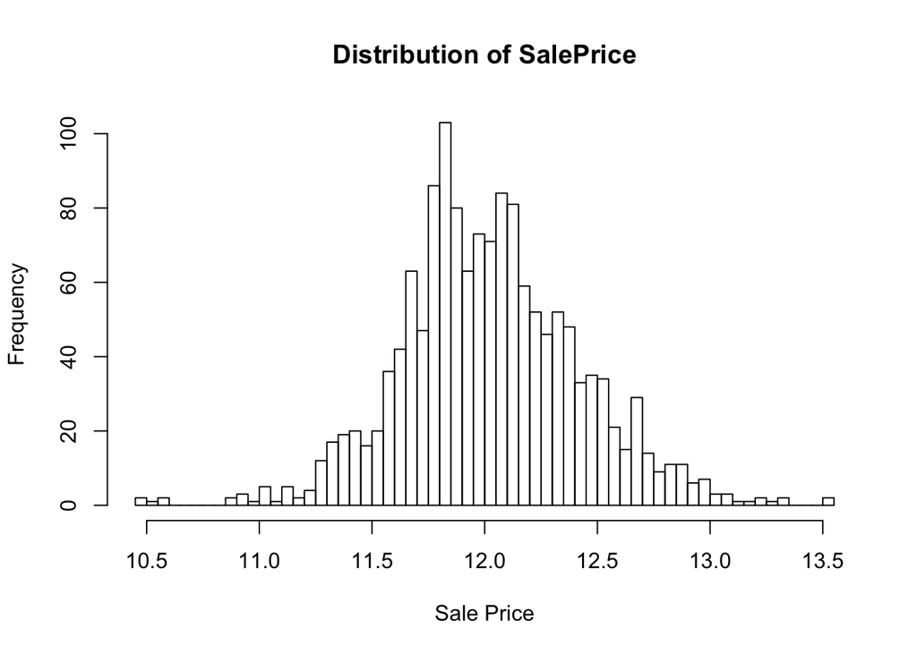

```r
hist(log(df$SalePrice), breaks = 50, main = "Distribution of SalePrice", xlab = "Sale Price")
```

```r
skewness(log(df$SalePrice))
```

```
## [1] 0.1213182
```

```r
kurtosis(log(df$SalePrice))
```

```
## [1] 0.7926861
```

```r
df$SalePrice = log(df$SalePrice)
```

So, after taking the logarithm, `SalePrice` is almost normal distribution.

```r
skewed = apply(df_numeric, 2, skewness)
skewed = skewed[(skewed>0.8) | (skewed< -0.8)]

kurtosis = apply(df_numeric, 2, kurtosis)
kurtosis = kurtosis[(kurtosis > 3.0) | (kurtosis < -3.0)]


for(col in names(skewed)){
  if(0 %in% df_numeric[, col]){
    df_numeric[,col] = log(1+df_numeric[,col])
  }else{
    df_numeric[,col] = log(df_numeric[,col])
  }
}

scaler = preProcess(df_numeric)
df_numeric = predict(scaler, df_numeric)

#Final DataFrame
df_final = cbind(df_numeric, df_categoric)
```

#### Feature Selection

Some of these features may have become zero-variance predictors, such that a few samples may have an insignificant influence on the model. These near-zero-variance may cause overfitting or will prevent our model from generalizing over the data at a more sufficient rate. The package caret offers a function nearZeroVar, which checks the frequency of the most common value over the second most frequent value, which would be closer to 1 for well-behaved predictors and very large for highly-unbalanced features. It also checks the number of unique values divided by the n number of samples which will approach zero as the level of detail in the feature increases. We can remove all of the near-zero-variance variables from out dataframe.

```r
nzv.data = nearZeroVar(df_final, saveMetrics = T)
drop.cols = rownames(nzv.data)[nzv.data$nzv == TRUE]
df_final = df_final[,!names(df_final) %in% drop.cols]

paste('The dataframe now has', dim(df_final)[1], 'rows and', dim(df_final)[2], 'columns')
```

```
## [1] "The dataframe now has 2917 rows and 151 columns"
```

## Model Training

### XGBoost

#### Dataset transformation

```r
x_train = df_final[1:1458,]
y_train = df$SalePrice

x_test = df_final[1459:nrow(df_final),]

dtrain = xgb.DMatrix(as.matrix(x_train), label = y_train)
dtest = xgb.DMatrix(as.matrix(x_test))
```

#### Parameters Tunning

```r
cv.ctrl = trainControl(method = 'repeatedcv', repeats = 1, number = 4, allowParallel = T)

#Tunning parameter range
xgb.grid = expand.grid(nrounds = 750, eta = c(0.01,0.005,0.001), max_depth = c(4,6,8),colsample_bytree=c(0,1,10),
        min_child_weight = 2,
        subsample=c(0,0.2,0.4,0.6),
        gamma=0.01)
set.seed(40)


#xgb_tune = train(as.matrix(x_train),
            # y_train,
            # method="xgbTree",
            # trControl=cv.ctrl,
            # tuneGrid=xgb.grid,
            # verbose=T,
            # metric="RMSE",
            # nthread =3)


xgb_params = list(
  booster = 'gbtree',
  objective = 'reg:linear',
  colsample_bytree=1,
  eta=0.005,
  max_depth=4,
  min_child_weight=3,
  alpha=0.3,
  lambda=0.4,
  gamma=0.01, # less overfit
  subsample=0.6,
  seed=5,
  silent=TRUE)
```

#### XGboost Model Training

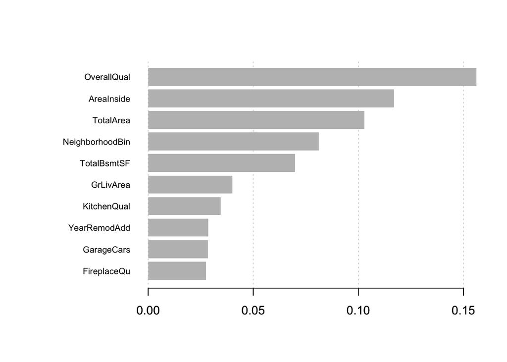

```r
bst = xgb.train(xgb_params, dtrain, nrounds = 10000)


rmse_eval = function(y.true, y.pred) {
  mse_eval = sum((y.true - exp(y.pred)-1)^2) / length(y.true)
  return(sqrt(mse_eval))
}


y_pred.xgb = as.double(predict(bst, dtest))
y_pred.xgb = as.double(exp(y_pred.xgb))


#We could check the variable importance
model.names = dimnames(dtrain)[[2]]
importance_matrix = xgb.importance(model.names, model = bst)
xgb.plot.importance(importance_matrix[1:10])
```

### Ridge and Lasso

We know there exists multicollinearity in our dependent variables as area features are a determinant for a house having a certain amount of rooms, we know that the garage variables have heavy dependency and the list goes on. Due to this a simple linear regression model will not be of much help to predict accurate sale prices, which is why we can make use of both ridge and lasso regression.

```r
glm.cv.ridge = cv.glmnet(as.matrix(x_train), y_train, alpha = 0)
glm.cv.lasso = cv.glmnet(as.matrix(x_train), y_train, alpha = 1)
glm.cv.net = cv.glmnet(data.matrix(x_train), y_train, alpha = 0.001)

# use the lamdba that minimizes the error
penalty.ridge = glm.cv.ridge$lambda.min
penalty.lasso = glm.cv.lasso$lambda.min
penalty.net = glm.cv.net$lambda.min

glm.ridge = glmnet(x = as.matrix(x_train), y = y_train, alpha = 0, lambda = penalty.ridge )
glm.lasso = glmnet(x = as.matrix(x_train), y = y_train, alpha = 1, lambda = penalty.lasso)
glm.net = glmnet(x = as.matrix(x_train), y = y_train, alpha = 0.001, lambda = penalty.net)

y_pred.ridge = as.numeric(predict(glm.ridge, as.matrix(x_train)))
y_pred.lasso = as.numeric(predict(glm.lasso, as.matrix(x_train)))
y_pred.net = as.numeric(predict(glm.net, as.matrix(x_train)))
```

### Final Boosting Result

```r
y_pred.ridge = as.double(predict(glm.ridge, as.matrix(x_test)))
y_pred.lasso = as.double(predict(glm.lasso, as.matrix(x_test)))
y_pred.net = as.double(predict(glm.net, as.matrix(x_test)))

y_pred.ridge = as.double(exp(y_pred.ridge))
y_pred.lasso = as.double(exp(y_pred.lasso))
y_pred.net = as.double(exp(y_pred.net))

y_pred.xgb = as.double(predict(bst, dtest))
y_pred.xgb = as.double(exp(y_pred.xgb))

# take the average of our predictions for our ensemble
y_pred = (y_pred.xgb + y_pred.ridge + y_pred.lasso + y_pred.net)/4.0

#result = data.frame(ID = c(1461:2919), SalePrice = y_pred)
#write.csv(result, 'result.csv', row.names = F)
```